# Aurel Sheremetaj Lindjet

## Ndërtimi i modelit MA(2)

```r
# Përcaktojmë rendin q
q_order <- 2

# Modelimi MA(2) mbi të dhënat e trajnimit (ts_train)
model_ma <- arima(ts_train, order = c(0, 0, q_order))

# Afishimi i Modelit MA(2)
cat("### Përmbledhja e Modelit MA(2) ###\n")
```

```
## ### Përmbledhja e Modelit MA(2) ###
```

```r
print(model_ma)
```

```
##
## Call:
## arima(x = ts_train, order = c(0, 0, q_order))
##
## Coefficients:
##          ma1     ma2  intercept
##       1.1204  0.5422  7670.9540
## s.e.  0.1245  0.1135   303.6274
##
## sigma^2 estimated as 671657:  log likelihood = -407.11,  aic = 822.22
```

```r
print(summary(model_ma))
```

```
##
## Call:
## arima(x = ts_train, order = c(0, 0, q_order))
##
## Coefficients:
##          ma1     ma2  intercept
##       1.1204  0.5422  7670.9540
## s.e.  0.1245  0.1135   303.6274
##
## sigma^2 estimated as 671657:  log likelihood = -407.11,  aic = 822.22
##
## Training set error measures:
##                     ME     RMSE      MAE        MPE     MAPE      MASE
## Training set 0.6767473 819.5467 680.5223 -0.9638114 8.847547 0.7552624
##                     ACF1
## Training set -0.08045017
```

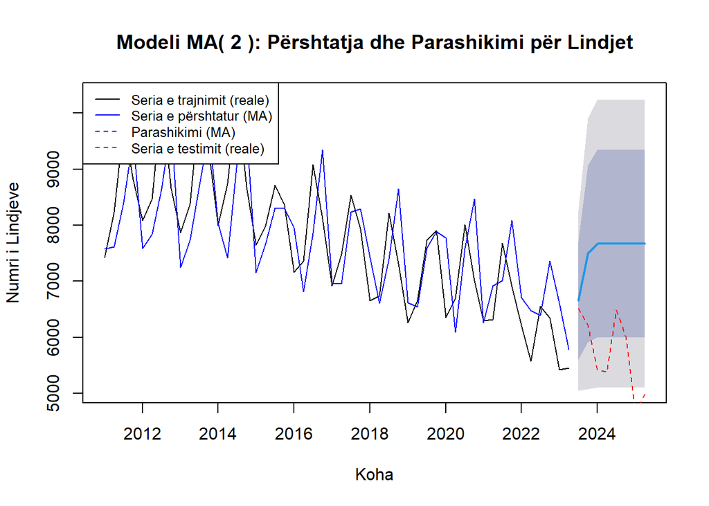

```r
# Parashikimi për modelin MA(q)
forecast_ma <- forecast(model_ma, h = h_test)


plot(forecast_ma,
     main = paste("Modeli MA(", q_order, "): Përshtatja dhe Parashikimi për Lindjet"),
     xlab = "Koha",
     ylab = "Numri i Lindjeve",
     xlim = range(time(ts_births)))


lines(fitted(model_ma), col = "blue")


lines(ts_test, col = "red", lty = 2)

legend("topleft",
       legend = c("Seria e trajnimit (reale)",
                  "Seria e përshtatur (MA)",
                  "Parashikimi (MA)",
                  "Seria e testimit (reale)"),
       col = c("black", "blue", "blue", "red"),
       lty = c(1, 1, 2, 2),
       cex = 0.8)
```

Modeli MA(2) përshtatet mirë me të dhënat historike, por parashikimet në periudhën e testimit tregojnë devijime nga vlerat reale.

```r
# Nxjerrim kohet nga ts_test
t_test <- time(ts_test)

# Konvertojmë në formatin Viti–Tremujori
Viti <- floor(t_test)
Tremujori <- round((t_test - Viti) * 4 + 1)
Periudha <- paste0(Viti, "-Q", Tremujori)

# Ndërtojmë tabelën e krahasimit
rez_ma <- data.frame(
  Periudha = Periudha,
  Parashikimi_MA = as.numeric(forecast_ma$mean),
  Vlera_Reale = as.numeric(ts_test)
)

print(head(rez_ma, 10))
```

```
##   Periudha Parashikimi_MA Vlera_Reale
## 1  2023-Q3       6653.211        6515
## 2  2023-Q4       7490.464        6226
## 3  2024-Q1       7670.954        5428
## 4  2024-Q2       7670.954        5380
## 5  2024-Q3       7670.954        6483
## 6  2024-Q4       7670.954        6019
## 7  2025-Q1       7670.954        4662
## 8  2025-Q2       7670.954        4982
```

Parashikimet e MA(2) janë të afërta në fillim të periudhës së testimit, por më pas modeli stabilizohet në një vlerë konstante dhe nuk pasqyron rënien reale të lindjeve, duke treguar kufizime në parashikimet afatgjata.

## Ndertimi i modelit AR(2)

```r
# Përcaktojmë rendin p
p_order <- 2

# Modelimi AR(2) mbi të dhënat e trajnimit (ts_train)
model_ar <- arima(ts_train, order = c(p_order, 0, 0))

# Afishimi i Modelit AR(2)
cat("### Përmbledhja e Modelit AR(2) ###\n")
```

```
## ### Përmbledhja e Modelit AR(2) ###
```

```r
print(model_ar)
```

```
##
## Call:
## arima(x = ts_train, order = c(p_order, 0, 0))
##
## Coefficients:
##          ar1      ar2  intercept
##       0.7306  -0.1555  7645.1715
## s.e.  0.1395   0.1443   302.6331
##
## sigma^2 estimated as 847558:  log likelihood = -412.48,  aic = 832.96
```

```r
print(summary(model_ar))
```

```
##
## Call:
## arima(x = ts_train, order = c(p_order, 0, 0))
##
## Coefficients:
##          ar1      ar2  intercept
##       0.7306  -0.1555  7645.1715
## s.e.  0.1395   0.1443   302.6331
##
## sigma^2 estimated as 847558:  log likelihood = -412.48,  aic = 832.96
##
## Training set error measures:
##                    ME     RMSE      MAE       MPE     MAPE      MASE      ACF1
## Training set 4.801098 920.6289 756.3603 -1.382462 9.885554 0.8394295 0.1202182
```

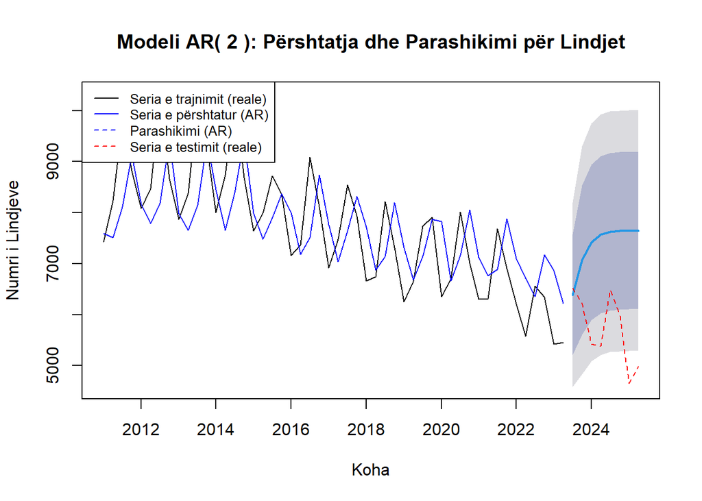

```r
# Parashikimi (Forecast) për periudhën e testimit
forecast_ar <- forecast(model_ar, h = h_test)


plot(forecast_ar,
     main = paste("Modeli AR(", p_order, "): Përshtatja dhe Parashikimi për Lindjet"),
     xlab = "Koha",
     ylab = "Numri i Lindjeve",
     xlim = range(time(ts_births)))


lines(fitted(model_ar), col = "blue")


lines(ts_test, col = "red", lty = 2)

legend("topleft",
       legend = c("Seria e trajnimit (reale)",
                  "Seria e përshtatur (AR)",
                  "Parashikimi (AR)",
                  "Seria e testimit (reale)"),
       col = c("black", "blue", "blue", "red"),
       lty = c(1, 1, 2, 2),
       cex = 0.8)
```

Modeli AR(2) përshtatet mirë me të dhënat historike, por parashikimet për periudhën e testimit dallojnë ndjeshëm nga vlerat reale. Kjo tregon se modeli kap strukturën afatshkurtër të serisë, por ka kufizime në parashikime afatgjata për shkak të variabilitetit të lartë të lindjeve.

```r
# Koha e ts_test si vite të plotë + tremujor
t_test <- time(ts_test)


Viti <- floor(t_test)
Tremujori <- round((t_test - Viti) * 4 + 1)
Periudha <- paste0(Viti, "-Q", Tremujori)


rez_ar <- data.frame(
  Periudha = Periudha,
  Parashikimi_AR = as.numeric(forecast_ar$mean),
  Vlera_Reale = as.numeric(ts_test)
)

print(head(rez_ar, 10))
```

```
##   Periudha Parashikimi_AR Vlera_Reale
## 1  2023-Q3       6388.134        6515
## 2  2023-Q4       7067.744        6226
## 3  2024-Q1       7418.734        5428
## 4  2024-Q2       7569.509        5380
## 5  2024-Q3       7625.098        6483
## 6  2024-Q4       7642.269        6019
## 7  2025-Q1       7646.172        4662
## 8  2025-Q2       7646.354        4982
```

Parashikimet AR janë të afërta në fillim të periudhës së testimit, por më pas modeli mbivlerëson lindjet dhe nuk kap rënien reale të serisë, duke treguar kufizime në parashikimet afatgjata.